# Step 1: Data Preprocessing

## 1.1 Load and inspect the dataset:

```python
import pandas as pd

# Load the dataset

df = pd.read_csv(r"C:\Users\Rajisha\Desktop\RAJISHA FINAL CAPSTONE PROJECT\Nutrical Dataset.csv")

# Display the first five rows of the dataset
df.head()
```

|  | Category | Item | Serving Size | Calories | Calories from Fat | Total Fat | Total Fat (% Daily Value) | Saturated Fat | Saturated Fat (% Daily Value) | Trans Fat | ... | Carbohydrates | Carbohydrates (% Daily Value) | Dietary Fiber | Dietary Fiber (% Daily Value) | Sugars | Protein | Vitamin A (% Daily Value) | Vitamin C (% Daily Value) | Calcium (% Daily Value) | Iron (% Daily Value) |
| --- | --- | --- | --- | --- | --- | --- | --- | --- | --- | --- | --- | --- | --- | --- | --- | --- | --- | --- | --- | --- | --- |
| 0 | Breakfast | Egg McMuffin | 4.8 oz (136 g) | 300 | 120 | 13.0 | 20 | 5.0 | 25 | 0.0 | ... | 31 | 10 | 4 | 17 | 3 | 17 | 10 | 0 | 25 | 15 |
| 1 | Breakfast | Egg White Delight | 4.8 oz (135 g) | 250 | 70 | 8.0 | 12 | 3.0 | 15 | 0.0 | ... | 30 | 10 | 4 | 17 | 3 | 18 | 6 | 0 | 25 | 8 |
| 2 | Breakfast | Sausage McMuffin | 3.9 oz (111 g) | 370 | 200 | 23.0 | 35 | 8.0 | 42 | 0.0 | ... | 29 | 10 | 4 | 17 | 2 | 14 | 8 | 0 | 25 | 10 |
| 3 | Breakfast | Sausage McMuffin with Egg | 5.7 oz (161 g) | 450 | 250 | 28.0 | 43 | 10.0 | 52 | 0.0 | ... | 30 | 10 | 4 | 17 | 2 | 21 | 15 | 0 | 30 | 15 |
| 4 | Breakfast | Sausage McMuffin with Egg Whites | 5.7 oz (161 g) | 400 | 210 | 23.0 | 35 | 8.0 | 42 | 0.0 | ... | 30 | 10 | 4 | 17 | 2 | 21 | 6 | 0 | 25 | 10 |

5 rows × 24 columns

```python
print(df.head())
```

```
    Category                              Item    Serving Size  Calories  \
0  Breakfast                      Egg McMuffin  4.8 oz (136 g)       300
1  Breakfast                 Egg White Delight  4.8 oz (135 g)       250
2  Breakfast                  Sausage McMuffin  3.9 oz (111 g)       370
3  Breakfast         Sausage McMuffin with Egg  5.7 oz (161 g)       450
4  Breakfast  Sausage McMuffin with Egg Whites  5.7 oz (161 g)       400

   Calories from Fat  Total Fat  Total Fat (% Daily Value)  Saturated Fat  \
0                120       13.0                         20            5.0
1                 70        8.0                         12            3.0
2                200       23.0                         35            8.0
3                250       28.0                         43           10.0
4                210       23.0                         35            8.0

   Saturated Fat (% Daily Value)  Trans Fat  ...  Carbohydrates  \
```

[output cut: 28 more lines]

```python
df.info()
```

```
<class 'pandas.core.frame.DataFrame'>
RangeIndex: 260 entries, 0 to 259
Data columns (total 24 columns):
 #   Column                         Non-Null Count  Dtype
---  ------                         --------------  -----
 0   Category                       260 non-null    object
 1   Item                           260 non-null    object
 2   Serving Size                   260 non-null    object
 3   Calories                       260 non-null    int64
 4   Calories from Fat              260 non-null    int64
 5   Total Fat                      260 non-null    float64
 6   Total Fat (% Daily Value)      260 non-null    int64
 7   Saturated Fat                  260 non-null    float64
 8   Saturated Fat (% Daily Value)  260 non-null    int64
 9   Trans Fat                      260 non-null    float64
```

[output cut: 16 more lines]

```python
len(df)
```

```
260
```

```python
df.columns
```

```
Index(['Category', 'Item', 'Serving Size', 'Calories', 'Calories from Fat',
       'Total Fat', 'Total Fat (% Daily Value)', 'Saturated Fat',
       'Saturated Fat (% Daily Value)', 'Trans Fat', 'Cholesterol',
       'Cholesterol (% Daily Value)', 'Sodium', 'Sodium (% Daily Value)',
       'Carbohydrates', 'Carbohydrates (% Daily Value)', 'Dietary Fiber',
       'Dietary Fiber (% Daily Value)', 'Sugars', 'Protein',
       'Vitamin A (% Daily Value)', 'Vitamin C (% Daily Value)',
       'Calcium (% Daily Value)', 'Iron (% Daily Value)'],
      dtype='object')
```

```python
len(df.columns)
```

```
24
```

## 1.2 Handle missing values and data cleaning:

```python
# Check for missing values
df.isnull().sum()
```

```
Category                         0
Item                             0
Serving Size                     0
Calories                         0
Calories from Fat                0
Total Fat                        0
Total Fat (% Daily Value)        0
Saturated Fat                    0
Saturated Fat (% Daily Value)    0
Trans Fat                        0
Cholesterol                      0
Cholesterol (% Daily Value)      0
Sodium                           0
Sodium (% Daily Value)           0
Carbohydrates                    0
Carbohydrates (% Daily Value)    0
Dietary Fiber                    0
Dietary Fiber (% Daily Value)    0
Sugars                           0
Protein                          0
Vitamin A (% Daily Value)        0
Vitamin C (% Daily Value)        0
Calcium (% Daily Value)          0
Iron (% Daily Value)             0
dtype: int64
```

- As we can see there are no missing values in this dataset, we are good to proceed further.

## Step 2: Exploratory Data Analysis (EDA)

## 2.1 Analyze the distribution of calorie counts:

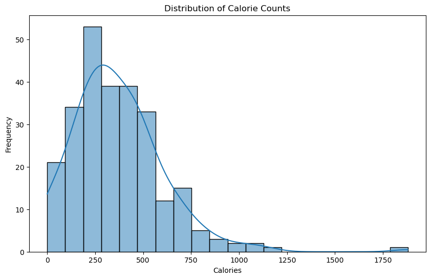

```python
import matplotlib.pyplot as plt
import seaborn as sns

# Distribution of calorie counts
plt.figure(figsize=(10, 6))
sns.histplot(df['Calories'], bins=20, kde=True)
plt.title('Distribution of Calorie Counts')
plt.xlabel('Calories')
plt.ylabel('Frequency')
plt.show()
```

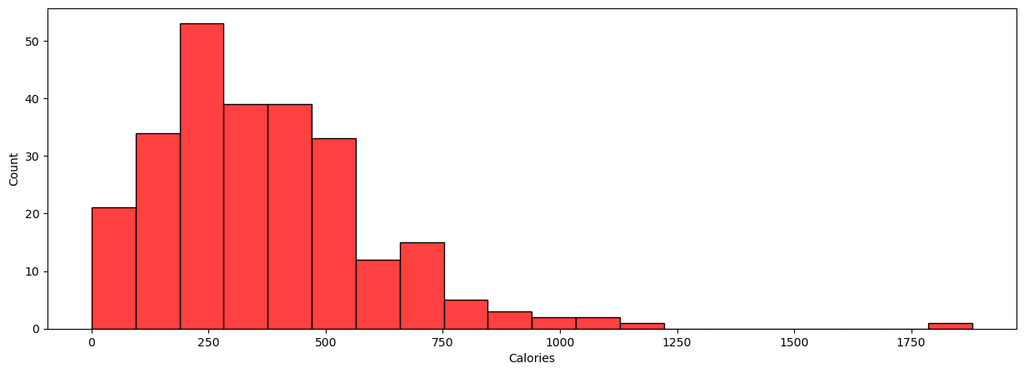

```python
import matplotlib.pyplot as plt
import seaborn as sns

# Create a figure and axis object
fig, ax = plt.subplots(figsize=(15, 5))

# Create a histogram using seaborn's histplot function
sns.histplot(x='Calories', data=df, ax=ax, color='red', bins=20)

# Show the plot
plt.show()
```

## 2.2 Explore the nutritional content:

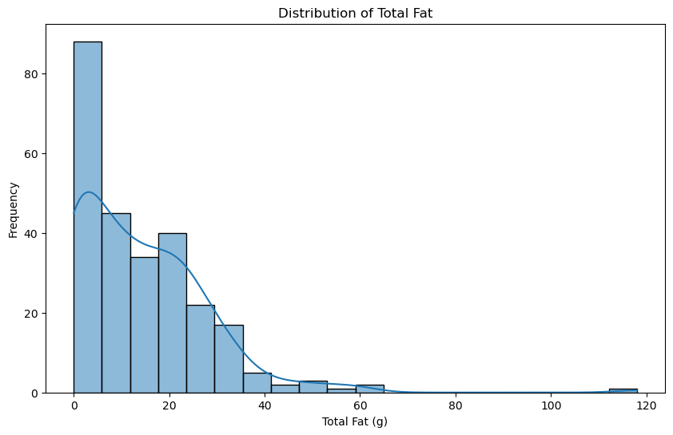

```python
# Distribution of fat content
plt.figure(figsize=(10, 6))
sns.histplot(df['Total Fat'], bins=20, kde=True)
plt.title('Distribution of Total Fat')
plt.xlabel('Total Fat (g)')
plt.ylabel('Frequency')
plt.show()
```

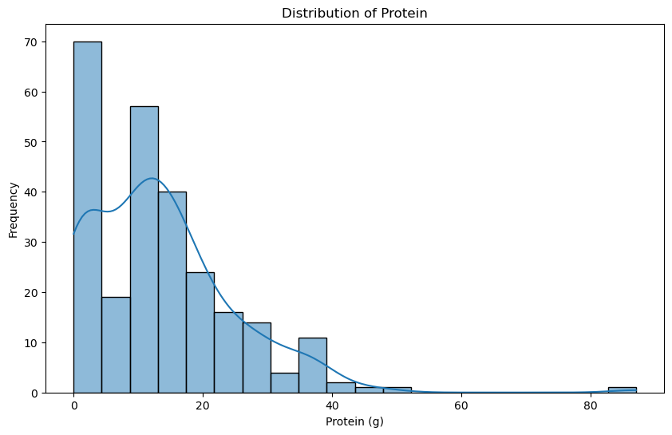

```python
# Distribution of Protein content
plt.figure(figsize=(10, 6))
sns.histplot(df['Protein'], bins=20, kde=True)
plt.title('Distribution of Protein')
plt.xlabel('Protein (g)')
plt.ylabel('Frequency')
plt.show()
```

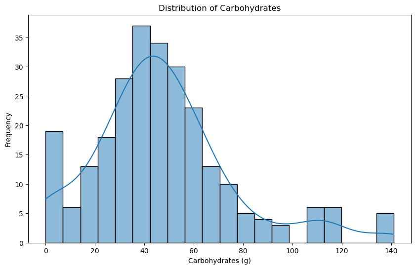

```python
# Distribution of Carbohydrates content
plt.figure(figsize=(10, 6))
sns.histplot(df['Carbohydrates'], bins=20, kde=True)
plt.title('Distribution of Carbohydrates')
plt.xlabel('Carbohydrates (g)')
plt.ylabel('Frequency')
plt.show()
```

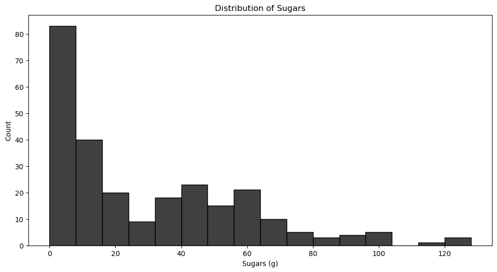

```python
import matplotlib.pyplot as plt
import seaborn as sns

# Create a figure and axis object
fig, ax = plt.subplots(figsize=(12, 6))

# Create a histogram using seaborn's histplot function
sns.histplot(x='Sugars', data=df, ax=ax, color='black', bins=16)

ax.set_title('Distribution of Sugars')
ax.set_xlabel('Sugars (g)')
ax.set_ylabel('Count')
plt.show()
```

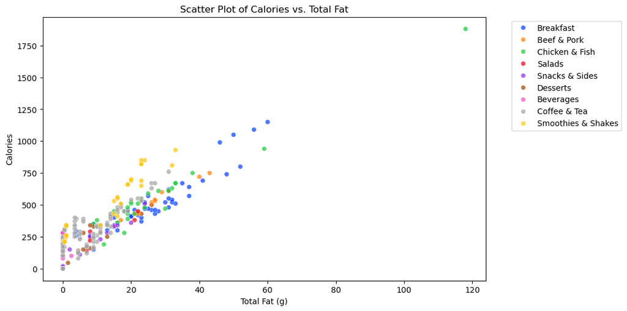

```python
# Scatter Plot of Calories vs. Total Fat
plt.figure(figsize=(10, 6))
sns.scatterplot(x='Total Fat', y='Calories', data=df, hue='Category', palette='bright', alpha=0.7)
plt.title('Scatter Plot of Calories vs. Total Fat')
plt.xlabel('Total Fat (g)')
plt.ylabel('Calories')
plt.legend(bbox_to_anchor=(1.05, 1), loc='upper left')
plt.show()
```

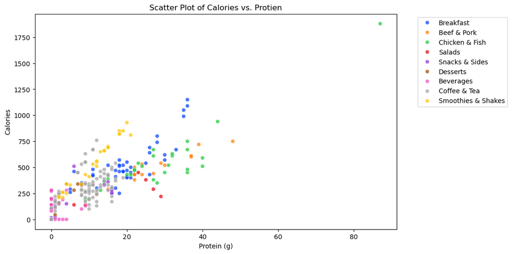

```python
# Scatter Plot of Calories vs. Protein
plt.figure(figsize=(10, 6))
sns.scatterplot(x='Protein', y='Calories', data=df, hue='Category', palette='bright', alpha=0.7)
plt.title('Scatter Plot of Calories vs. Protien')
plt.xlabel('Protein (g)')
plt.ylabel('Calories')
plt.legend(bbox_to_anchor=(1.05, 1), loc='upper left')
plt.show()
```

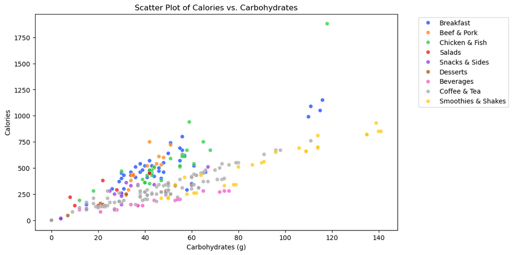

```python
# Scatter Plot of Calories vs. Carbohydrate
plt.figure(figsize=(10, 6))
sns.scatterplot(x='Carbohydrates', y='Calories', data=df, hue='Category', palette='bright', alpha=0.7)
plt.title('Scatter Plot of Calories vs. Carbohydrates')
plt.xlabel('Carbohydrates (g)')
plt.ylabel('Calories')
plt.legend(bbox_to_anchor=(1.05, 1), loc='upper left')
plt.show()
```

### 2.3 Identify trends and patterns:

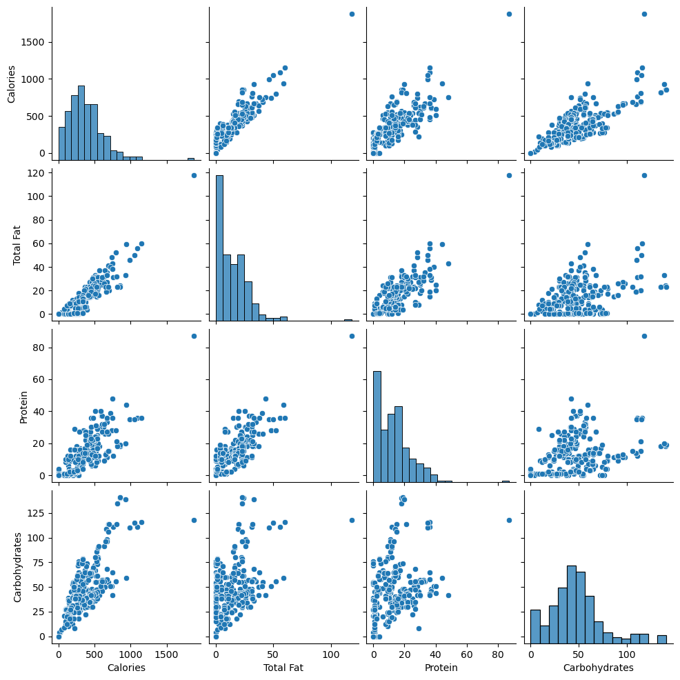

```python
# Pairplot to identify relationships between different nutritional components

sns.pairplot(df[['Calories', 'Total Fat', 'Protein', 'Carbohydrates']])
plt.show()
```

### 2.4. Correlation Matrix

```python
df.corr(numeric_only=True).round(2)
```

|  | Calories | Calories from Fat | Total Fat | Total Fat (% Daily Value) | Saturated Fat | Saturated Fat (% Daily Value) | Trans Fat | Cholesterol | Cholesterol (% Daily Value) | Sodium | ... | Carbohydrates | Carbohydrates (% Daily Value) | Dietary Fiber | Dietary Fiber (% Daily Value) | Sugars | Protein | Vitamin A (% Daily Value) | Vitamin C (% Daily Value) | Calcium (% Daily Value) | Iron (% Daily Value) |
| --- | --- | --- | --- | --- | --- | --- | --- | --- | --- | --- | --- | --- | --- | --- | --- | --- | --- | --- | --- | --- | --- |
| Calories | 1.00 | 0.90 | 0.90 | 0.90 | 0.85 | 0.85 | 0.52 | 0.60 | 0.60 | 0.71 | ... | 0.78 | 0.78 | 0.54 | 0.54 | 0.26 | 0.79 | 0.11 | -0.07 | 0.43 | 0.64 |
| Calories from Fat | 0.90 | 1.00 | 1.00 | 1.00 | 0.85 | 0.85 | 0.43 | 0.68 | 0.68 | 0.85 | ... | 0.46 | 0.46 | 0.58 | 0.58 | -0.12 | 0.81 | 0.06 | -0.09 | 0.16 | 0.74 |
| Total Fat | 0.90 | 1.00 | 1.00 | 1.00 | 0.85 | 0.85 | 0.43 | 0.68 | 0.68 | 0.85 | ... | 0.46 | 0.46 | 0.58 | 0.58 | -0.12 | 0.81 | 0.05 | -0.09 | 0.16 | 0.73 |
| Total Fat (% Daily Value) | 0.90 | 1.00 | 1.00 | 1.00 | 0.85 | 0.85 | 0.43 | 0.68 | 0.68 | 0.85 | ... | 0.46 | 0.46 | 0.58 | 0.58 | -0.12 | 0.81 | 0.05 | -0.09 | 0.16 | 0.74 |
| Saturated Fat | 0.85 | 0.85 | 0.85 | 0.85 | 1.00 | 1.00 | 0.62 | 0.63 | 0.63 | 0.58 | ... | 0.59 | 0.59 | 0.35 | 0.35 | 0.20 | 0.60 | 0.06 | -0.18 | 0.40 | 0.58 |
| Saturated Fat (% Daily Value) | 0.85 | 0.85 | 0.85 | 0.85 | 1.00 | 1.00 | 0.62 | 0.63 | 0.63 | 0.59 | ... | 0.59 | 0.59 | 0.36 | 0.35 | 0.20 | 0.61 | 0.07 | -0.18 | 0.40 | 0.58 |
| Trans Fat | 0.52 | 0.43 | 0.43 | 0.43 | 0.62 | 0.62 | 1.00 | 0.25 | 0.25 | 0.19 | ... | 0.46 | 0.46 | 0.05 | 0.06 | 0.33 | 0.39 | 0.08 | -0.08 | 0.39 | 0.33 |
| Cholesterol | 0.60 | 0.68 | 0.68 | 0.68 | 0.63 | 0.63 | 0.25 | 1.00 | 1.00 | 0.62 | ... | 0.27 | 0.27 | 0.44 | 0.44 | -0.14 | 0.56 | 0.08 | -0.08 | 0.13 | 0.65 |
| Cholesterol (% Daily Value) | 0.60 | 0.68 | 0.68 | 0.68 | 0.63 | 0.63 | 0.25 | 1.00 | 1.00 | 0.62 | ... | 0.27 | 0.27 | 0.43 | 0.44 | -0.14 | 0.56 | 0.08 | -0.08 | 0.13 | 0.65 |
| Sodium | 0.71 | 0.85 | 0.85 | 0.85 | 0.58 | 0.59 | 0.19 | 0.62 | 0.62 | 1.00 | ... | 0.20 | 0.20 | 0.69 | 0.69 | -0.43 | 0.87 | 0.08 | -0.03 | -0.02 | 0.87 |
| Sodium (% Daily Value) | 0.71 | 0.85 | 0.85 | 0.85 | 0.59 | 0.59 | 0.19 | 0.62 | 0.62 | 1.00 | ... | 0.20 | 0.20 | 0.69 | 0.69 | -0.42 | 0.87 | 0.08 | -0.03 | -0.02 | 0.87 |
| Carbohydrates | 0.78 | 0.46 | 0.46 | 0.46 | 0.59 | 0.59 | 0.46 | 0.27 | 0.27 | 0.20 | ... | 1.00 | 1.00 | 0.22 | 0.23 | 0.76 | 0.35 | 0.08 | -0.03 | 0.59 | 0.21 |
| Carbohydrates (% Daily Value) | 0.78 | 0.46 | 0.46 | 0.46 | 0.59 | 0.59 | 0.46 | 0.27 | 0.27 | 0.20 | ... | 1.00 | 1.00 | 0.22 | 0.23 | 0.76 | 0.35 | 0.08 | -0.04 | 0.59 | 0.21 |
| Dietary Fiber | 0.54 | 0.58 | 0.58 | 0.58 | 0.35 | 0.36 | 0.05 | 0.44 | 0.43 | 0.69 | ... | 0.22 | 0.22 | 1.00 | 0.99 | -0.30 | 0.64 | 0.34 | 0.14 | 0.03 | 0.74 |
| Dietary Fiber (% Daily Value) | 0.54 | 0.58 | 0.58 | 0.58 | 0.35 | 0.35 | 0.06 | 0.44 | 0.44 | 0.69 | ... | 0.23 | 0.23 | 0.99 | 1.00 | -0.29 | 0.66 | 0.36 | 0.15 | 0.05 | 0.74 |
| Sugars | 0.26 | -0.12 | -0.12 | -0.12 | 0.20 | 0.20 | 0.33 | -0.14 | -0.14 | -0.43 | ... | 0.76 | 0.76 | -0.30 | -0.29 | 1.00 | -0.18 | 0.05 | -0.07 | 0.60 | -0.36 |
| Protein | 0.79 | 0.81 | 0.81 | 0.81 | 0.60 | 0.61 | 0.39 | 0.56 | 0.56 | 0.87 | ... | 0.35 | 0.35 | 0.64 | 0.66 | -0.18 | 1.00 | 0.21 | -0.05 | 0.33 | 0.79 |
| Vitamin A (% Daily Value) | 0.11 | 0.06 | 0.05 | 0.05 | 0.06 | 0.07 | 0.08 | 0.08 | 0.08 | 0.08 | ... | 0.08 | 0.08 | 0.34 | 0.36 | 0.05 | 0.21 | 1.00 | 0.07 | 0.18 | 0.14 |
| Vitamin C (% Daily Value) | -0.07 | -0.09 | -0.09 | -0.09 | -0.18 | -0.18 | -0.08 | -0.08 | -0.08 | -0.03 | ... | -0.03 | -0.04 | 0.14 | 0.15 | -0.07 | -0.05 | 0.07 | 1.00 | -0.22 | 0.00 |
| Calcium (% Daily Value) | 0.43 | 0.16 | 0.16 | 0.16 | 0.40 | 0.40 | 0.39 | 0.13 | 0.13 | -0.02 | ... | 0.59 | 0.59 | 0.03 | 0.05 | 0.60 | 0.33 | 0.18 | -0.22 | 1.00 | 0.03 |
| Iron (% Daily Value) | 0.64 | 0.74 | 0.73 | 0.74 | 0.58 | 0.58 | 0.33 | 0.65 | 0.65 | 0.87 | ... | 0.21 | 0.21 | 0.74 | 0.74 | -0.36 | 0.79 | 0.14 | 0.00 | 0.03 | 1.00 |

21 rows × 21 columns

# Step 3: Data Visualization

## 3.1 Create bar charts, histograms, and box plots:

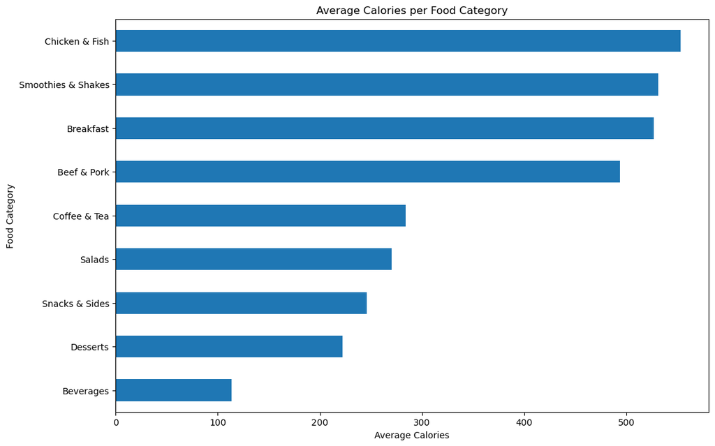

```python
# Bar chart for average calories per food category
avg_calories_per_category = df.groupby('Category')['Calories'].mean().sort_values()
plt.figure(figsize=(12, 8))
avg_calories_per_category.plot(kind='barh')
plt.title('Average Calories per Food Category')
plt.xlabel('Average Calories')
plt.ylabel('Food Category')
plt.show()
```

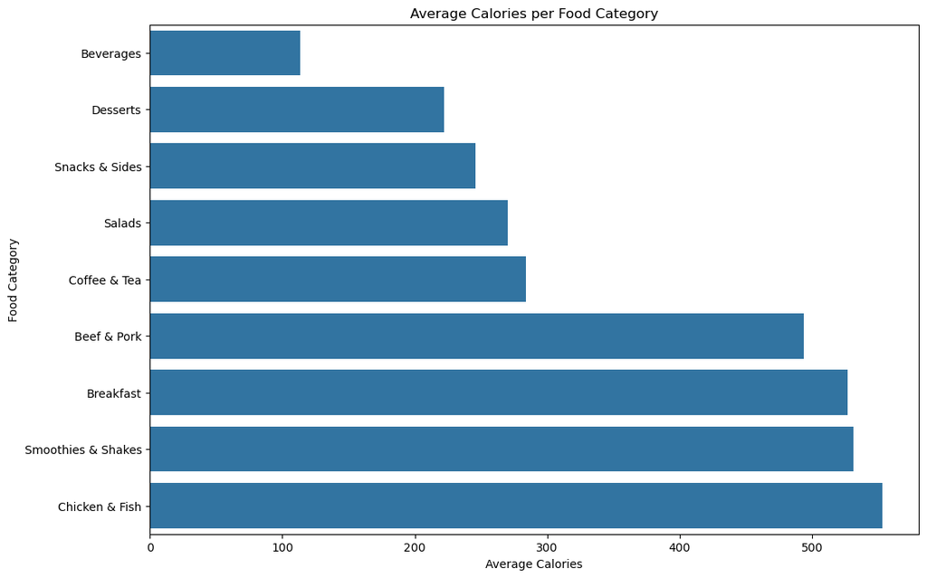

```python
# Plot the bar chart
plt.figure(figsize=(12, 8))
sns.barplot(x=avg_calories_per_category.values, y=avg_calories_per_category.index)
plt.title('Average Calories per Food Category')
plt.xlabel('Average Calories')
plt.ylabel('Food Category')
plt.show()
```

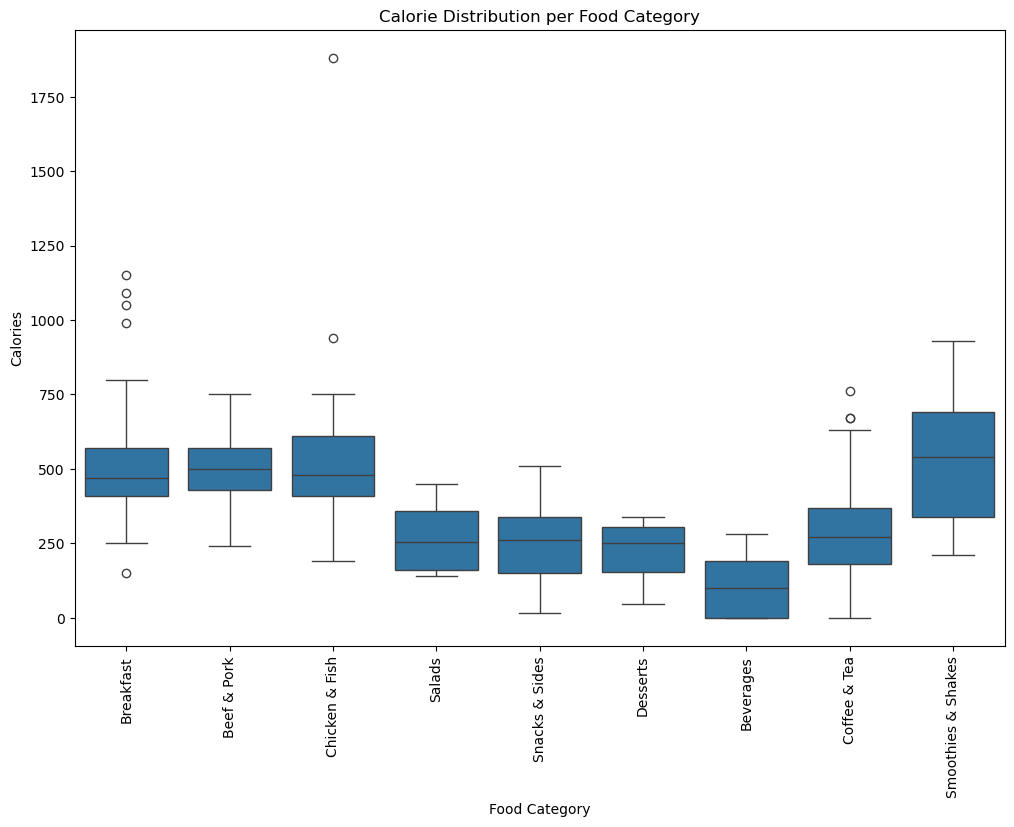

```python
# Box plot for calorie distribution per category
plt.figure(figsize=(12, 8))
sns.boxplot(x='Category', y='Calories', data=df)
plt.xticks(rotation=90)
plt.title('Calorie Distribution per Food Category')
plt.xlabel('Food Category')
plt.ylabel('Calories')
plt.show()
```

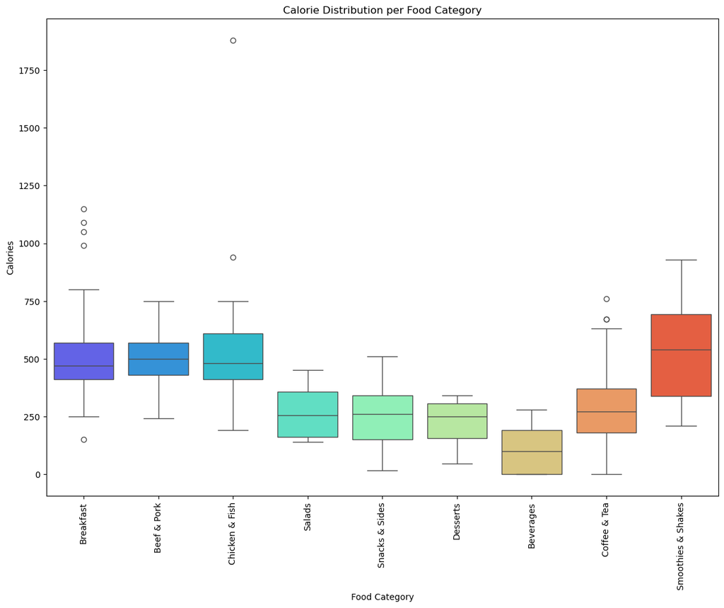

```python
# Box plot for calorie distribution per category
plt.figure(figsize=(14, 10))
sns.boxplot(x='Category', y='Calories', data=df, hue='Category', palette='rainbow', dodge=False, legend=False)
plt.xticks(rotation=90)
plt.title('Calorie Distribution per Food Category')
plt.xlabel('Food Category')
plt.ylabel('Calories')
plt.show()
```

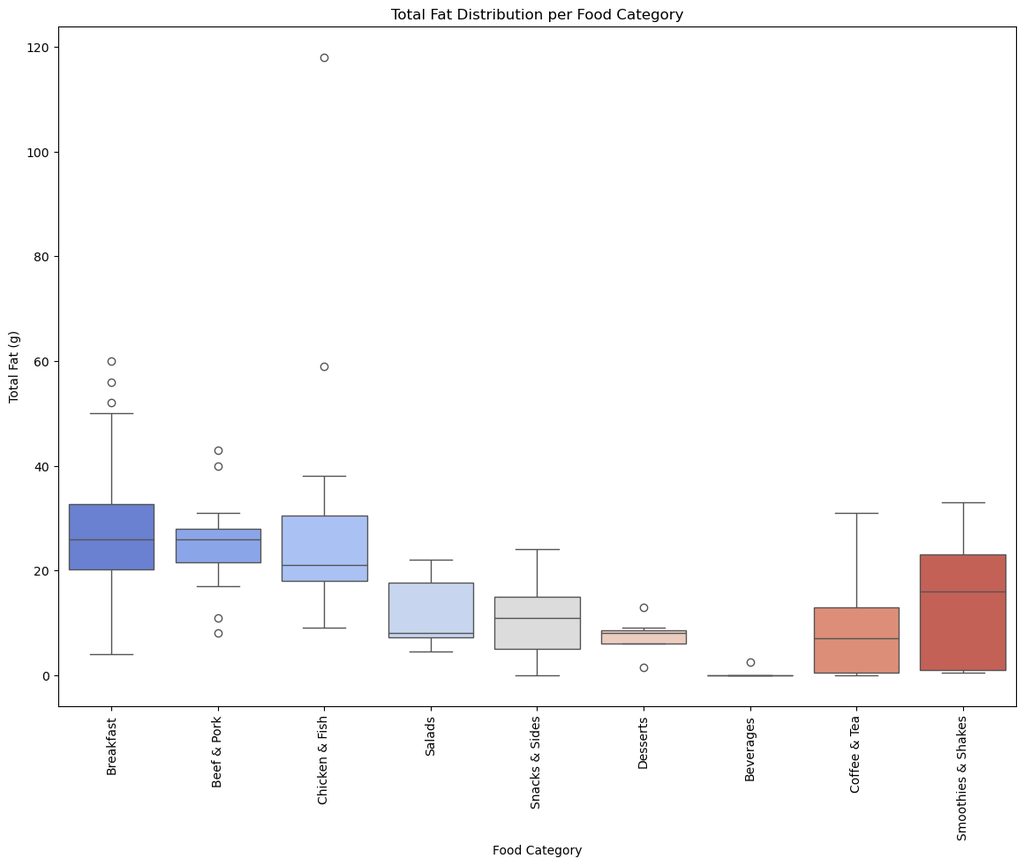

```python
# Box plot for total fat distribution per category
plt.figure(figsize=(14, 10))
sns.boxplot(x='Category', y='Total Fat', data=df, hue='Category', palette='coolwarm', dodge=False, legend=False)
plt.xticks(rotation=90)
plt.title('Total Fat Distribution per Food Category')
plt.xlabel('Food Category')
plt.ylabel('Total Fat (g)')
plt.show()
```

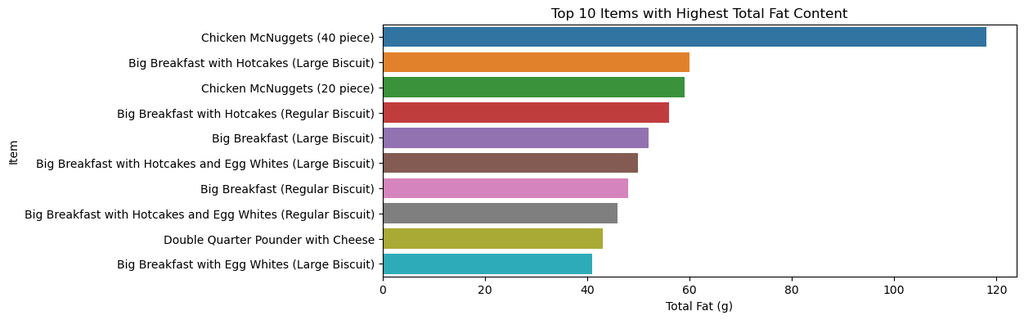

```python
# Top 10 Items with Highest Total Fat Content
max_fat = df.sort_values('Total Fat', ascending=False).head(10)

fig, ax = plt.subplots(figsize=(10, 4))
sns.barplot(x='Total Fat', y='Item', data=max_fat, ax=ax, hue='Item')

ax.set_title('Top 10 Items with Highest Total Fat Content')
ax.set_xlabel('Total Fat (g)')
ax.set_ylabel('Item')

plt.show()
```

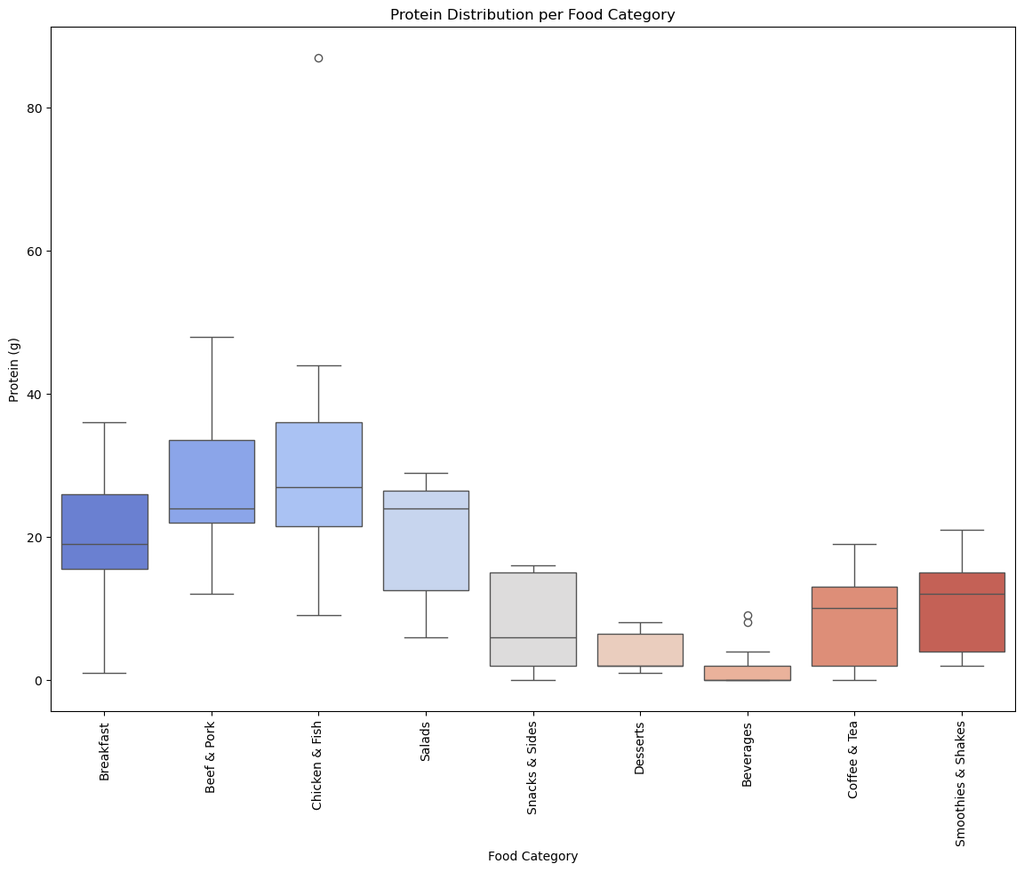

```python
# Box plot for protein distribution per category
plt.figure(figsize=(14, 10))
sns.boxplot(x='Category', y='Protein', data=df, hue='Category', palette='coolwarm', dodge=False, legend=False)
plt.xticks(rotation=90)
plt.title('Protein Distribution per Food Category')
plt.xlabel('Food Category')
plt.ylabel('Protein (g)')
plt.show()
```

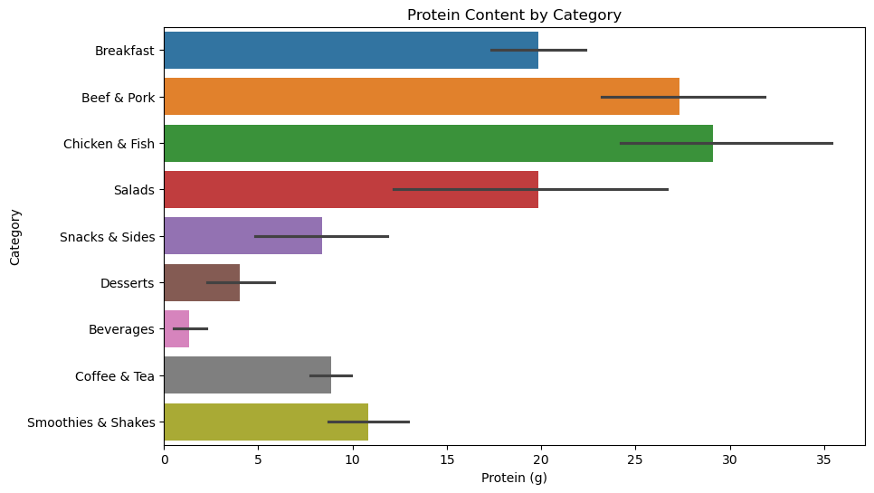

```python
# Protein Content by Category
fig, ax = plt.subplots(figsize=(10, 6))

sns.barplot(x='Protein', y='Category', data=df, ax=ax, hue='Category')

ax.set_title('Protein Content by Category')
ax.set_xlabel('Protein (g)')
ax.set_ylabel('Category')

plt.show()
```

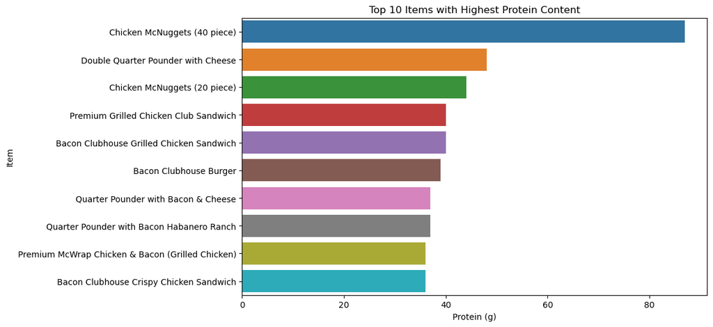

```python
# Top 10 items with the highest Protein content
max_protein = df.sort_values('Protein', ascending=False).head(10)

fig, ax = plt.subplots(figsize=(10, 6))

sns.barplot(x='Protein', y='Item', data=max_protein, ax=ax, hue='Item')

ax.set_title('Top 10 Items with Highest Protein Content')
ax.set_xlabel('Protein (g)')
ax.set_ylabel('Item')
plt.show()
```

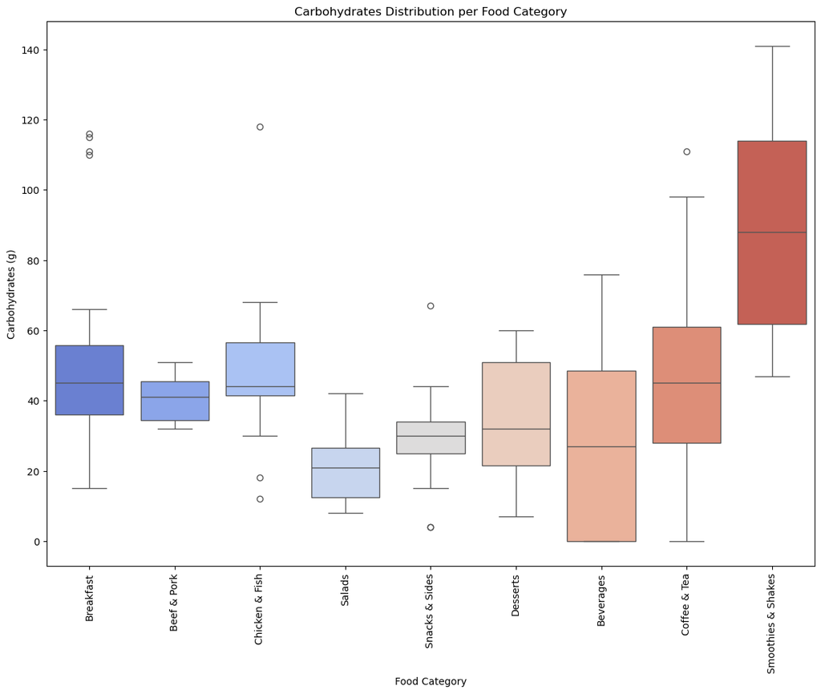

```python
# Box plot for carbohydrate distribution per category
plt.figure(figsize=(14, 10))
sns.boxplot(x='Category', y='Carbohydrates', data=df, hue='Category', palette='coolwarm', dodge=False, legend=False)
plt.xticks(rotation=90)
plt.title('Carbohydrates Distribution per Food Category')
plt.xlabel('Food Category')
plt.ylabel('Carbohydrates (g)')
plt.show()
```

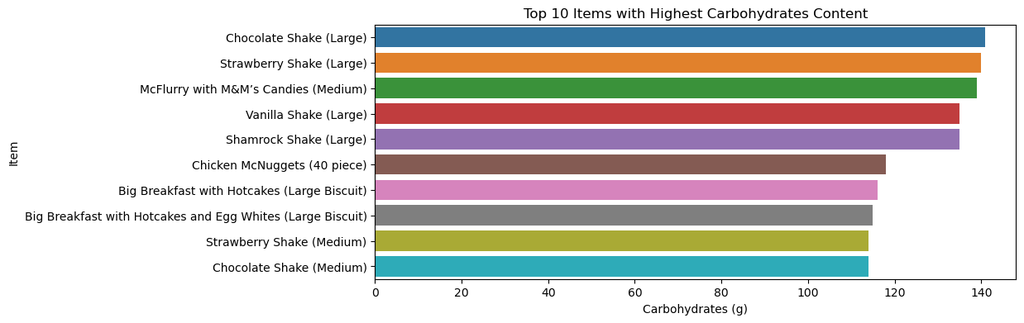

```python
# The top 10 items with the highest Carbohydrates content
max_carb = df.sort_values('Carbohydrates', ascending=False).head(10)

fig, ax = plt.subplots(figsize=(10, 4))
sns.barplot(x='Carbohydrates', y='Item', data=max_carb, ax=ax, hue='Item')

ax.set_title('Top 10 Items with Highest Carbohydrates Content')
ax.set_xlabel('Carbohydrates (g)')
ax.set_ylabel('Item')
plt.show()
```

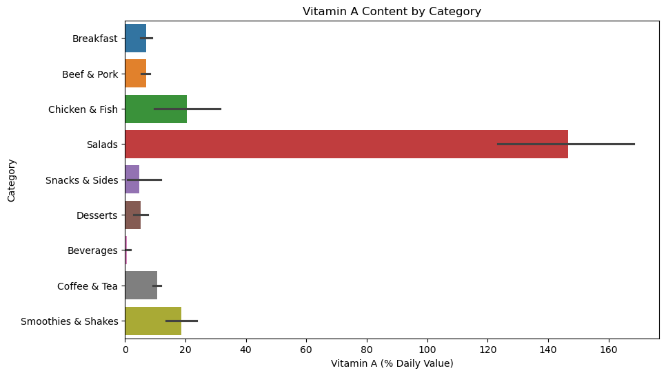

```python
# Vitamin A Content by Category
fig, ax = plt.subplots(figsize=(10, 6))

sns.barplot(x='Vitamin A (% Daily Value)', y='Category', data=df, ax=ax, hue='Category')

ax.set_title('Vitamin A Content by Category')
ax.set_xlabel('Vitamin A (% Daily Value)')
ax.set_ylabel('Category')

plt.show()
```

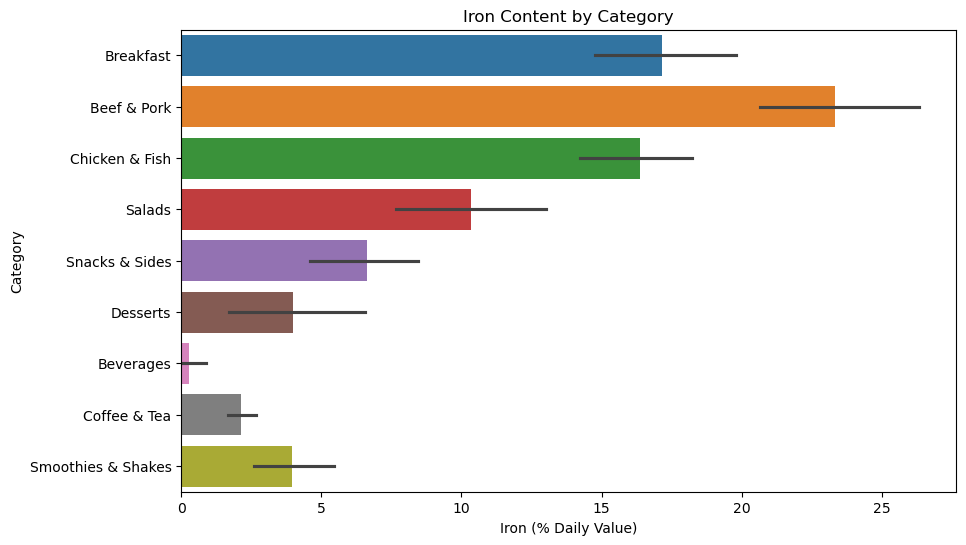

```python
# Iron Content by Category
fig, ax = plt.subplots(figsize=(10, 6))

sns.barplot(x='Iron (% Daily Value)', y='Category', data=df, ax=ax, hue='Category')

ax.set_title('Iron Content by Category')
ax.set_xlabel('Iron (% Daily Value)')
ax.set_ylabel('Category')
plt.show()
```

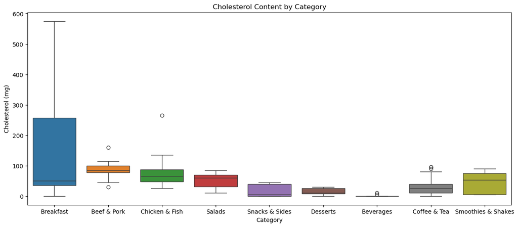

```python
# Cholesterol Content by Category
fig, ax = plt.subplots(figsize=(15, 6))

sns.boxplot(x='Category', y='Cholesterol', data=df, ax=ax, hue='Category')

# Add a title and labels
ax.set_title('Cholesterol Content by Category')
ax.set_xlabel('Category')
ax.set_ylabel('Cholesterol (mg)')

plt.show()
```

## Step 4: Nutrition-Based Insights

### 4.1 Identify menu items with the highest and lowest calorie counts:

```python
# Highest calorie items
df.nlargest(10, 'Calories')[['Item', 'Category', 'Calories']]
```

|  | Item | Category | Calories |
| --- | --- | --- | --- |
| 82 | Chicken McNuggets (40 piece) | Chicken & Fish | 1880 |
| 32 | Big Breakfast with Hotcakes (Large Biscuit) | Breakfast | 1150 |
| 31 | Big Breakfast with Hotcakes (Regular Biscuit) | Breakfast | 1090 |
| 34 | Big Breakfast with Hotcakes and Egg Whites (La... | Breakfast | 1050 |
| 33 | Big Breakfast with Hotcakes and Egg Whites (Re... | Breakfast | 990 |
| 81 | Chicken McNuggets (20 piece) | Chicken & Fish | 940 |
| 253 | McFlurry with M&M’s Candies (Medium) | Smoothies & Shakes | 930 |
| 246 | Strawberry Shake (Large) | Smoothies & Shakes | 850 |
| 249 | Chocolate Shake (Large) | Smoothies & Shakes | 850 |
| 243 | Vanilla Shake (Large) | Smoothies & Shakes | 820 |

```python
# Lowest calorie items
df.nsmallest(10, 'Calories')[['Item', 'Category', 'Calories']]
```

|  | Item | Category | Calories |
| --- | --- | --- | --- |
| 114 | Diet Coke (Small) | Beverages | 0 |
| 115 | Diet Coke (Medium) | Beverages | 0 |
| 116 | Diet Coke (Large) | Beverages | 0 |
| 117 | Diet Coke (Child) | Beverages | 0 |
| 122 | Diet Dr Pepper (Small) | Beverages | 0 |
| 123 | Diet Dr Pepper (Medium) | Beverages | 0 |
| 124 | Diet Dr Pepper (Large) | Beverages | 0 |
| 125 | Diet Dr Pepper (Child) | Beverages | 0 |
| 136 | Dasani Water Bottle | Beverages | 0 |
| 137 | Iced Tea (Small) | Coffee & Tea | 0 |

### 4.2 Determine the average nutritional content of popular menu categories:

```python
# Average nutritional content per category
numeric_columns = df.select_dtypes(include='number').columns
numeric_df = df[numeric_columns]
df.groupby('Category')[numeric_columns].mean().round(2)
```

| Category | Calories | Calories from Fat | Total Fat | Total Fat (% Daily Value) | Saturated Fat | Saturated Fat (% Daily Value) | Trans Fat | Cholesterol | Cholesterol (% Daily Value) | Sodium | ... | Carbohydrates | Carbohydrates (% Daily Value) | Dietary Fiber | Dietary Fiber (% Daily Value) | Sugars | Protein | Vitamin A (% Daily Value) | Vitamin C (% Daily Value) | Calcium (% Daily Value) | Iron (% Daily Value) |
| --- | --- | --- | --- | --- | --- | --- | --- | --- | --- | --- | --- | --- | --- | --- | --- | --- | --- | --- | --- | --- | --- |
| Beef & Pork | 494.00 | 224.67 | 24.87 | 38.60 | 10.47 | 52.00 | 1.10 | 87.33 | 28.93 | 1020.67 | ... | 40.13 | 13.47 | 2.53 | 9.87 | 8.80 | 27.33 | 6.93 | 7.33 | 23.00 | 23.33 |
| Beverages | 113.70 | 0.74 | 0.09 | 0.15 | 0.06 | 0.30 | 0.00 | 0.56 | 0.19 | 41.48 | ... | 28.81 | 9.59 | 0.04 | 0.07 | 27.85 | 1.33 | 0.74 | 23.48 | 2.96 | 0.30 |
| Breakfast | 526.67 | 248.93 | 27.69 | 42.67 | 10.65 | 53.43 | 0.11 | 152.86 | 50.95 | 1211.07 | ... | 49.76 | 16.57 | 3.26 | 12.83 | 8.26 | 19.86 | 6.93 | 8.90 | 16.17 | 17.14 |
| Chicken & Fish | 552.96 | 242.22 | 26.96 | 41.33 | 6.17 | 31.11 | 0.13 | 75.37 | 25.22 | 1257.78 | ... | 49.07 | 16.33 | 2.93 | 11.81 | 7.33 | 29.11 | 20.44 | 12.63 | 15.44 | 16.37 |
| Coffee & Tea | 283.89 | 71.11 | 8.02 | 12.36 | 4.92 | 24.37 | 0.14 | 27.26 | 9.38 | 136.89 | ... | 44.53 | 14.86 | 0.78 | 3.18 | 39.61 | 8.86 | 10.74 | 0.00 | 28.29 | 2.15 |
| Desserts | 222.14 | 64.29 | 7.36 | 11.14 | 4.29 | 21.29 | 0.00 | 15.00 | 4.86 | 117.14 | ... | 34.86 | 11.57 | 1.00 | 3.43 | 26.14 | 4.00 | 5.14 | 4.14 | 11.43 | 4.00 |
| Salads | 270.00 | 108.33 | 11.75 | 18.33 | 3.75 | 18.50 | 0.00 | 51.67 | 17.33 | 588.33 | ... | 21.67 | 7.17 | 4.50 | 18.50 | 6.83 | 19.83 | 146.67 | 28.33 | 15.00 | 10.33 |
| Smoothies & Shakes | 531.43 | 127.68 | 14.12 | 21.71 | 8.38 | 41.79 | 0.54 | 45.00 | 14.71 | 183.57 | ... | 90.43 | 30.14 | 1.46 | 5.75 | 77.89 | 10.86 | 18.75 | 6.96 | 35.57 | 3.96 |
| Snacks & Sides | 245.77 | 94.62 | 10.54 | 16.23 | 2.69 | 13.38 | 0.00 | 18.46 | 6.23 | 395.77 | ... | 29.15 | 9.62 | 1.54 | 7.08 | 4.08 | 8.38 | 4.85 | 28.15 | 6.00 | 6.62 |

9 rows × 21 columns

# Analysis and Reporting

## Summary of Findings and Insights from the Analysis

### 3. Correlation Analysis:

- There is a strong positive correlation between calories and total fat, indicating that higher-calorie items tend to have higher fat content.
- Calories also show a positive correlation with protein and sodium, suggesting that high-calorie items are typically richer in these nutrients as well.
- Carbohydrates and sugars are strongly correlated, which is expected as sugars contribute significantly to the carbohydrate content.

# Benefits of Nutritional Analysis for McDonald's Customers and the Organization

## Benefits for Customers

1. **Informed Choices:**
- Nutritional transparency allows customers to make informed decisions about their food choices.
- By understanding the nutritional content of each menu item, customers can choose meals that align with their dietary goals and health needs.
2. **Healthier Alternatives:**
- With clear information, customers can identify healthier options.
- For instance, they might opt for salads or grilled chicken items over higher-calorie burgers and fried foods.
3. **Dietary Management:**
- Customers with specific dietary requirements, such as low sodium or low sugar diets, can use this information to select appropriate menu items, aiding in better health management.
4. **Portion Control:**
- Knowing the calorie content of menu items can help customers practice portion control, thereby avoiding excessive calorie intake.

## Benefits for the Organization

1. **Enhanced Customer Trust:**
- Providing detailed nutritional information enhances transparency and builds trust with customers, showing McDonald's commitment to their health and well-being.
2. **Market Differentiation:**
- In an increasingly health-conscious market, offering detailed nutritional information can differentiate McDonald's from competitors and attract health-conscious consumers.
3. **Menu Optimization:**
- Nutritional analysis can help McDonald's identify areas for menu improvement. For example, reducing sodium content in high-sodium items or offering lower-calorie versions of popular menu items can cater to health-conscious consumers.
4. **Targeted Marketing:**
- Understanding the nutritional profiles of menu items allows McDonald's to better target their marketing efforts. For instance, they can promote items that align with popular dietary trends, such as high-protein or low-carb diets.
5. **Regulatory Compliance:**
- Detailed nutritional information ensures compliance with regulatory requirements regarding food labeling and nutritional transparency, avoiding potential legal issues and enhancing corporate responsibility.
6. **Customer Feedback and Innovation:**

Analyzing customer preferences based on nutritional data can provide insights into consumer trends, enabling McDonald's to innovate and introduce new items that meet the evolving demands of their customer base.

## Recommendations for McDonald's

1. **Introduce Healthier Options:**
- Expand the menu to include more items that are low in calories, fat, and sodium. For example, offer more salads, grilled options, and fruit-based desserts.
2. **Nutritional Labeling:**
- Ensure that all menu items have clear and accessible nutritional labeling, both in-store and online, to help customers make informed choices.
3. **Reformulate Recipes:**
- Consider reformulating high-sodium, high-fat, and high-sugar items to reduce these components without compromising on taste.
4. **Portion Sizes:**
- Offer smaller portion sizes for high-calorie items to provide customers with more choices and control over their calorie intake.
5. **Customer Education:**
- Launch campaigns to educate customers about the importance of balanced nutrition and how to make healthier choices from the McDonald's menu.
6. **Sustainability and Sourcing:**
- Emphasize sustainability and healthier sourcing practices, such as using organic ingredients, reducing additives, and ensuring high-quality nutritional standards.

By implementing these recommendations, McDonald's can improve the nutritional profile of its menu, cater to the growing demand for healthier food options, and enhance its brand image as a responsible and customer-focused organization.